# Difference Plots

# Goal

This notebook shows how to compare groups by plotting differences directly.

It adapts the clinical-course habit of moving from many separate bars to a focused difference plot.

# Analytic Questions

We will ask:

- How do PRAMS alcohol-use estimates differ from binge-drinking estimates?
- Which states have the largest gaps between the two estimates?
- Why might a difference plot be clearer than two bars per state?

# Load Data

```r
prams_path <- "data/real/prams_2011_selected.csv"

prams <- read_csv(prams_path, show_col_types = FALSE)
```

# Prepare Data

PRAMS values are already aggregated percentages for state/subgroup rows.

```r
state_overall <- prams |>
  filter(
    subgroup_cat == "None",
    !is.na(alcohol_use_within_3_months_birth),
    !is.na(binge_drinking_within_3_months_birth)
  ) |>
  transmute(
    location,
    alcohol_use = alcohol_use_within_3_months_birth,
    binge_drinking = binge_drinking_within_3_months_birth,
    difference = alcohol_use - binge_drinking
  ) |>
  arrange(difference)

state_overall
```

```
# A tibble: 26 × 4
   location      alcohol_use binge_drinking difference
   <chr>               <dbl>          <dbl>      <dbl>
 1 Utah                 23.5           12.4       11.1
 2 Georgia              34.1           12.6       21.5
 3 West Virginia        42.1           17.1       25
 4 Arkansas             49.6           23.9       25.7
 5 New York City        42.3           14.9       27.4
 6 New Mexico           49.6           20.7       28.9
 7 Hawaii               53.1           24         29.1
 8 Wyoming              58.6           28.2       30.4
 9 Oklahoma             48.5           17.9       30.6
10 Nebraska             64.7           33.4       31.3
# ℹ 16 more rows
```

# Two Bars Per State

First, compare the two estimates using paired bars.

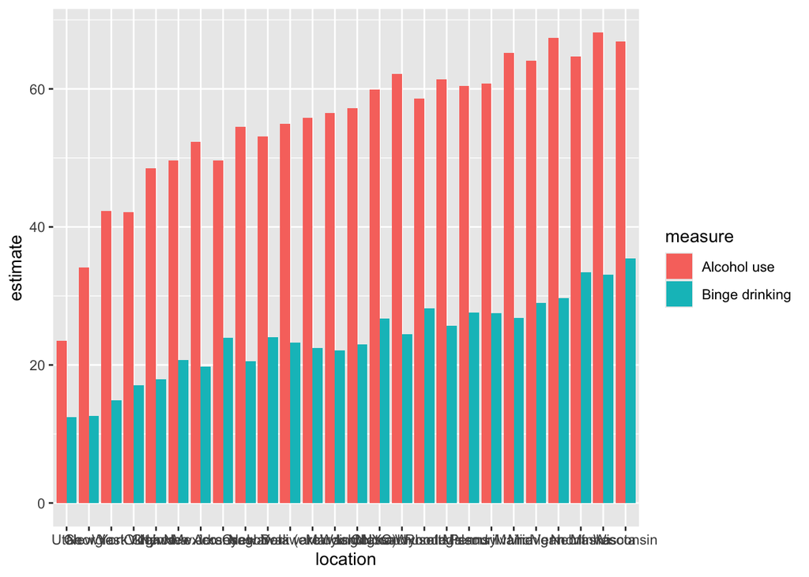

```r
paired_estimates <- state_overall |>
  select(location, alcohol_use, binge_drinking) |>
  tidyr::pivot_longer(
    cols = c(alcohol_use, binge_drinking),
    names_to = "measure",
    values_to = "estimate"
  ) |>
  mutate(
    measure = recode(
      measure,
      alcohol_use = "Alcohol use",
      binge_drinking = "Binge drinking"
    ),
    location = reorder(location, estimate)
  )

p1 <- ggplot(paired_estimates, aes(x = location, y = estimate, fill = measure)) +
  geom_col(position = "dodge")

p1
```

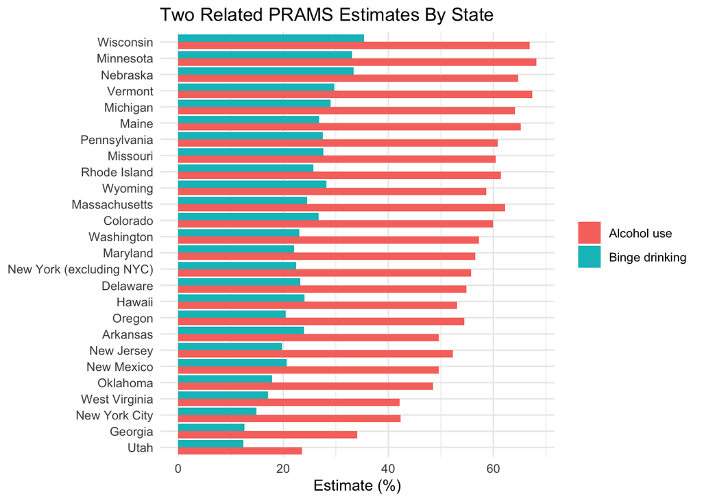

```r
p2 <- p1 +
  coord_flip() +
  labs(
    title = "Two Related PRAMS Estimates By State",
    x = NULL,
    y = "Estimate (%)",
    fill = NULL
  ) +
  theme_minimal()

p2
```

# Plot The Difference Directly

If the question is about the gap, calculate and plot the gap.

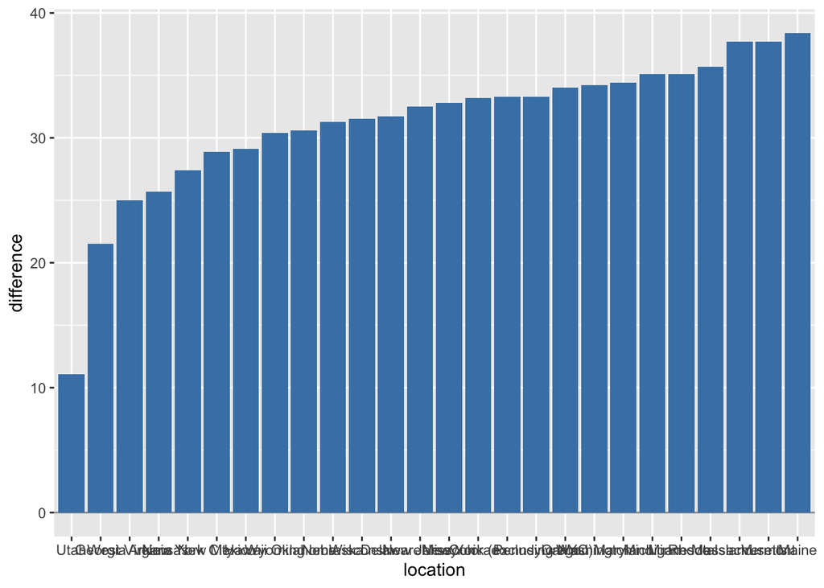

```r
difference_data <- state_overall |>
  mutate(location = reorder(location, difference))

p1 <- ggplot(difference_data, aes(x = location, y = difference)) +
  geom_hline(yintercept = 0, color = "gray60") +
  geom_col(fill = "steelblue")

p1
```

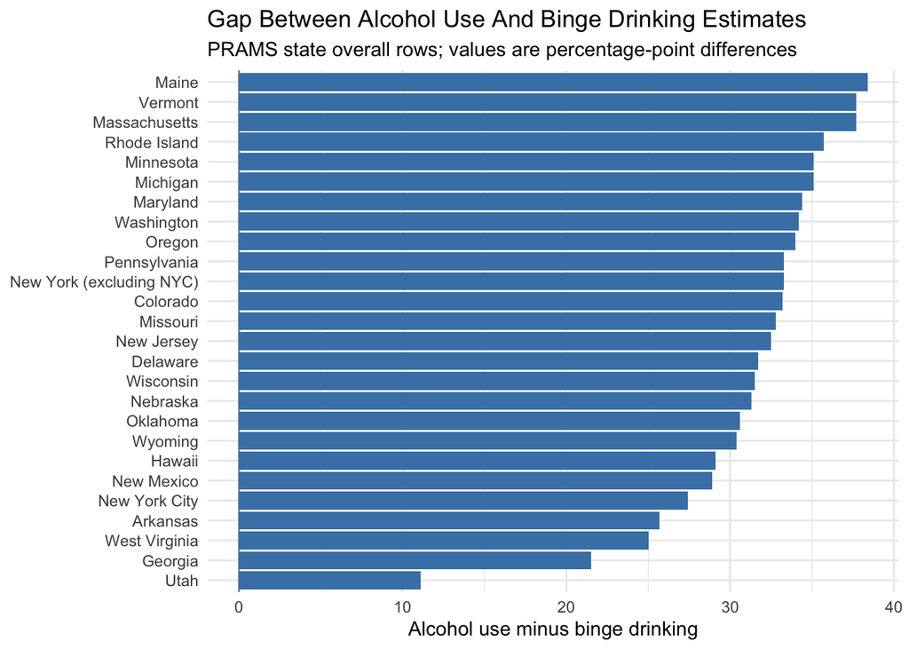

```r
p2 <- p1 +
  coord_flip() +
  labs(
    title = "Gap Between Alcohol Use And Binge Drinking Estimates",
    subtitle = "PRAMS state overall rows; values are percentage-point differences",
    x = NULL,
    y = "Alcohol use minus binge drinking"
  ) +
  theme_minimal()

p2
```

Interpretation: the difference plot makes the size of the gap easier to compare across states than the paired bar plot. The values are state-level PRAMS percentages, not individual-level outcomes.

# Takeaways

- If the question is about a difference, plot the difference.
- Difference plots reduce visual clutter when paired comparisons are the focus.
- Always label whether differences are percentage points, raw units, ratios, or percent changes.